# Members

Facilitator(s): Zenan Wang, Taixi Lu Recorder(s): Zoey Ye Deliverer(s): Jiahuan He Planner(s): Yvonne Qiu Contact: Taixi Lu

# Dataset

Our dataset is tweets from 03-16-2020 to 04-14-2020. There are 6 variables: UserName, ScreenName, Location, TweetAt, OriginalTweet, and Sentiment.

“UserName” and “ScreenName” are two varibles to identify the rows, and they seem to be reduntant. We can use a new column names “id.” “Location” stands for the place where the tweet was posted. “TweetAt” is the date of the tweet. “OriginalTweet” is the tweet message, and “Sentiment” is the mental state of the person who posted the current tweet.

The dimention of the data is 41157x6.

Our goal of interest is the Sentiment column.

The data can be found at Kaggle with the link: https://www.kaggle.com/datatattle/covid-19-nlp-text-classification

# Motivations and Goals

Everyone’s life has been dramatically changed since COVID started. People are facing more difficulties at work, school, and daily lives. And mental health issues have been a serious public health question. According to a research by NHIS, the average share of aults reporting anxiety and depression has increased from 11.0% in 2019 to 41.1% in 2021. But what can we do to help and care for those who are depressed? What we are trying to find in this project is how COVID has affected our emotions based on tweet posts, and how we can predict the users’ emotions based on their tweets. This is meaningful because we can learn what factors are producing depression, and what factors can help improve our appetite for life. This result can be used in companies and school to prevent employees’ and students’ from being too stressful and maintain good mental health conditions.

# EDA

```r
library(tidyverse)
library(textstem)
library(reticulate)
library(NLP)
```

```r
library(knitr)
library(wordcloud)
library(RColorBrewer)
library(wordcloud2)
library(tm)
```

## Import Data and Some Cleaning

Our data has 6 columns: UserName, ScreenName, Location, TweetAt, OriginalTweet, and Sentiment, then we use head(data) to take a brief look at the data and interpret what each variable stands for.

“UserName” and “ScreenName” are two varibles to identify the rows, and they seem to be reduntant. We can use a new column names “id.” “Location” stands for the place where the tweet was posted. “TweetAt” is the date of the tweet. “OriginalTweet” is the tweet message, and “Sentiment” is the mental state of the person who posted the current tweet.

The dimention of the data is 41157x6.

```r
data <- read.csv("Corona_NLP_train.csv", encoding = "UTF-8")
head(data)
```

```
##   UserName ScreenName                 Location    TweetAt
## 1     3799      48751                   London 16-03-2020
## 2     3800      48752                       UK 16-03-2020
## 3     3801      48753                Vagabonds 16-03-2020
## 4     3802      48754                          16-03-2020
## 5     3803      48755                          16-03-2020
## 6     3804      48756 üT: 36.319708,-82.363649 16-03-2020
##                                                                                                                                                                                                                                                                                                        Or…
## 1                                                                                                                                                                                                    @MeNyrbie @Phil_Gahan @Chrisitv https://t.co/iFz9FAn2Pa and https://t.co/xX6ghGFzCC and https://t.co…
## 2                                                                      advice Talk to your neighbours family to exchange phone numbers create contact list with phone numbers of neighbours schools employer chemist GP set up online shopping accounts if poss adequate supplies of regular meds but not…
## 3                                                                                                                                                                                Coronavirus Australia: Woolworths to give elderly, disabled dedicated shopping hours amid COVID-19 outbreak https://t.co…
## 4      My food stock is not the only one which is empty...\n\nPLEASE, don't panic, THERE WILL BE ENOUGH FOOD FOR EVERYONE if you do not take more than you need. \nStay calm, stay safe.\n\n#COVID19france #COVID_19 #COVID19 #coronavirus #confinement #Confinementotal #ConfinementGeneral https://t.co…
## 5 Me, ready to go at supermarket during the #COVID19 outbreak.\n\nNot because I'm paranoid, but because my food stock is litteraly empty. The #coronavirus is a serious thing, but please, don't panic. It causes shortage...\n\n#CoronavirusFrance #restezchezvous #StayAtHome #confinement https://t.co…
## 6                                                   As news of the regions first confirmed COVID-19 case came out of Sullivan County last week, people flocked to area stores to purchase cleaning supplies, hand sanitizer, food, toilet paper and other goods, @Tim_Dodson reports https://t.co/cfXch7a…
##            Sentiment
## 1            Neutral
## 2           Positive
## 3           Positive
## 4           Positive
## 5 Extremely Negative
## 6           Positive
```

```r
names(data)
```

```
## [1] "UserName"      "ScreenName"    "Location"      "TweetAt"
## [5] "OriginalTweet" "Sentiment"
```

```r
dim(data)
```

```
## [1] 41157     6
```

## Explore the variables we have

```r
data <- data %>%
  mutate(TweetAt = as.factor(TweetAt ), Sentiment = as.factor(Sentiment))

levels((data$TweetAt))
```

```
##  [1] "01-04-2020" "02-04-2020" "03-04-2020" "04-04-2020" "05-04-2020"
##  [6] "06-04-2020" "07-04-2020" "08-04-2020" "09-04-2020" "10-04-2020"
## [11] "11-04-2020" "12-04-2020" "13-04-2020" "14-04-2020" "16-03-2020"
## [16] "17-03-2020" "18-03-2020" "19-03-2020" "20-03-2020" "21-03-2020"
## [21] "22-03-2020" "23-03-2020" "24-03-2020" "25-03-2020" "26-03-2020"
## [26] "27-03-2020" "28-03-2020" "29-03-2020" "30-03-2020" "31-03-2020"
```

```r
levels((data$Sentiment))
```

```
## [1] "Extremely Negative" "Extremely Positive" "Negative"
## [4] "Neutral"            "Positive"
```

```r
length(unique(data$UserName))
```

```
## [1] 41157
```

```r
length(unique(data$ScreenName))
```

```
## [1] 41157
```

We use a new “id” column to substitute “UserName” and “ScreeName.”

```r
data <- data %>%
  select(c(-1,-2)) %>%
  mutate(id = c(1:41157)) %>%
  select(c(5,1,2,3,4))

head(data)
```

```
##   id                 Location    TweetAt
## 1  1                   London 16-03-2020
## 2  2                       UK 16-03-2020
## 3  3                Vagabonds 16-03-2020
## 4  4                          16-03-2020
## 5  5                          16-03-2020
## 6  6 üT: 36.319708,-82.363649 16-03-2020
##                                                                                                                                                                                                                                                                                                        Or…
## 1                                                                                                                                                                                                    @MeNyrbie @Phil_Gahan @Chrisitv https://t.co/iFz9FAn2Pa and https://t.co/xX6ghGFzCC and https://t.co…
## 2                                                                      advice Talk to your neighbours family to exchange phone numbers create contact list with phone numbers of neighbours schools employer chemist GP set up online shopping accounts if poss adequate supplies of regular meds but not…
## 3                                                                                                                                                                                Coronavirus Australia: Woolworths to give elderly, disabled dedicated shopping hours amid COVID-19 outbreak https://t.co…
## 4      My food stock is not the only one which is empty...\n\nPLEASE, don't panic, THERE WILL BE ENOUGH FOOD FOR EVERYONE if you do not take more than you need. \nStay calm, stay safe.\n\n#COVID19france #COVID_19 #COVID19 #coronavirus #confinement #Confinementotal #ConfinementGeneral https://t.co…
## 5 Me, ready to go at supermarket during the #COVID19 outbreak.\n\nNot because I'm paranoid, but because my food stock is litteraly empty. The #coronavirus is a serious thing, but please, don't panic. It causes shortage...\n\n#CoronavirusFrance #restezchezvous #StayAtHome #confinement https://t.co…
## 6                                                   As news of the regions first confirmed COVID-19 case came out of Sullivan County last week, people flocked to area stores to purchase cleaning supplies, hand sanitizer, food, toilet paper and other goods, @Tim_Dodson reports https://t.co/cfXch7a…
##            Sentiment
## 1            Neutral
## 2           Positive
## 3           Positive
## 4           Positive
## 5 Extremely Negative
## 6           Positive
```

## Add more columns to the data for interpretation

Since the column “OriginalTweet” is a long list of char, it is hard for interpretation. We move extract some information from this column to create new variables. Here, “TweetLength” is the number of character. “NumUpperCase” is the number of upper case characters. “AtPresent” is a binary indicator that shows whether there is an “@” character (or whether the poster wanted others to see the tweet). We also changed “Location” to be a factor because the date is discrete. Note we didn’t create thes columns randomly. “Tokenied” is a list of words based on the OriginalTweet (seperate the tweet into a list of words divided by space). These variables are what we think to be related to our goal of interest, which is the Sentiment column.

```r
data <- data %>%
  mutate(TweetLength = nchar(OriginalTweet, allowNA = TRUE, keepNA = TRUE),
         NumUpperCase = str_count(OriginalTweet, "[A-Z]"),
         AtPresent = grepl( "@", iconv(OriginalTweet, "UTF-8", "UTF-8",sub=''), fixed = TRUE),
         Location = as.factor(Location)) %>%
         na.omit()

str_split(data[1,]$OriginalTweet, " ")
```

```
## [[1]]
## [1] "@MeNyrbie"               "@Phil_Gahan"
## [3] "@Chrisitv"               "https://t.co/iFz9FAn2Pa"
## [5] "and"                     "https://t.co/xX6ghGFzCC"
## [7] "and"                     "https://t.co/I2NlzdxNo8"
```

```r
data <- data %>%
  mutate(tokenized = str_split("1 2 3", " "))
```

```r
for (i in 1:nrow(data)) {
  print(i)
  data[i,]$tokenized = str_split(data[i,]$OriginalTweet, " ")
}
```

```r
data$tokenized[[1]]
```

```
## [1] "@MeNyrbie"               "@Phil_Gahan"
## [3] "@Chrisitv"               "https://t.co/iFz9FAn2Pa"
## [5] "and"                     "https://t.co/xX6ghGFzCC"
## [7] "and"                     "https://t.co/I2NlzdxNo8"
```

```r
head(data)
```

```
##   id                 Location    TweetAt
## 1  1                   London 16-03-2020
## 2  2                       UK 16-03-2020
## 3  3                Vagabonds 16-03-2020
## 4  4                          16-03-2020
## 5  5                          16-03-2020
## 6  6 üT: 36.319708,-82.363649 16-03-2020
##                                                                                                                                                                                                                                                                                                        Or…
## 1                                                                                                                                                                                                    @MeNyrbie @Phil_Gahan @Chrisitv https://t.co/iFz9FAn2Pa and https://t.co/xX6ghGFzCC and https://t.co…
## 2                                                                      advice Talk to your neighbours family to exchange phone numbers create contact list with phone numbers of neighbours schools employer chemist GP set up online shopping accounts if poss adequate supplies of regular meds but not…
## 3                                                                                                                                                                                Coronavirus Australia: Woolworths to give elderly, disabled dedicated shopping hours amid COVID-19 outbreak https://t.co…
## 4      My food stock is not the only one which is empty...\n\nPLEASE, don't panic, THERE WILL BE ENOUGH FOOD FOR EVERYONE if you do not take more than you need. \nStay calm, stay safe.\n\n#COVID19france #COVID_19 #COVID19 #coronavirus #confinement #Confinementotal #ConfinementGeneral https://t.co…
## 5 Me, ready to go at supermarket during the #COVID19 outbreak.\n\nNot because I'm paranoid, but because my food stock is litteraly empty. The #coronavirus is a serious thing, but please, don't panic. It causes shortage...\n\n#CoronavirusFrance #restezchezvous #StayAtHome #confinement https://t.co…
## 6                                                   As news of the regions first confirmed COVID-19 case came out of Sullivan County last week, people flocked to area stores to purchase cleaning supplies, hand sanitizer, food, toilet paper and other goods, @Tim_Dodson reports https://t.co/cfXch7a…
##            Sentiment TweetLength NumUpperCase AtPresent
## 1            Neutral         111           17      TRUE
## 2           Positive         237            3     FALSE
## 3           Positive         131           13     FALSE
## 4           Positive         296           60     FALSE
## 5 Extremely Negative         302           16     FALSE
## 6           Positive         249           12      TRUE
##                                                                                                                                                                                                                                                                                                          …
## 1                                                                                                                                                                                                                                  @MeNyrbie, @Phil_Gahan, @Chrisitv, https://t.co/iFz9FAn2Pa, and, https…
## 2                                                                      advice, Talk, to, your, neighbours, family, to, exchange, phone, numbers, create, contact, list, with, phone, numbers, of, neighbours, schools, employer, chemist, GP, set, up, online, shopping, accounts, if, poss, adequate, su…
## 3                                                                                                                                                                                                        Coronavirus, Australia:, Woolworths, to, give, elderly,, disabled, dedicated, shopping, hours, a…
## 4    My, food, stock, is, not, the, only, one, which, is, empty...\n\nPLEASE,, don't, panic,, THERE, WILL, BE, ENOUGH, FOOD, FOR, EVERYONE, if, you, do, not, take, more, than, you, need., \nStay, calm,, stay, safe.\n\n#COVID19france, #COVID_19, #COVID19, #coronavirus, #confinement, #Confinementot…
## 5 Me,, ready, to, go, at, supermarket, during, the, #COVID19, outbreak.\n\nNot, because, I'm, paranoid,, but, because, my, food, stock, is, litteraly, empty., The, #coronavirus, is, a, serious, thing,, but, please,, don't, panic., It, causes, shortage...\n\n#CoronavirusFrance, #restezchezvous, #S…
## 6                                                     As, news, of, the, regions, first, confirmed, COVID-19, case, came, out, of, Sullivan, County, last, week,, people, flocked, to, area, stores, to, purchase, cleaning, supplies,, hand, sanitizer,, food,, toilet, paper, and, other, goods,, @Tim_…
```

## Distribution of the variables using histogram and barplot

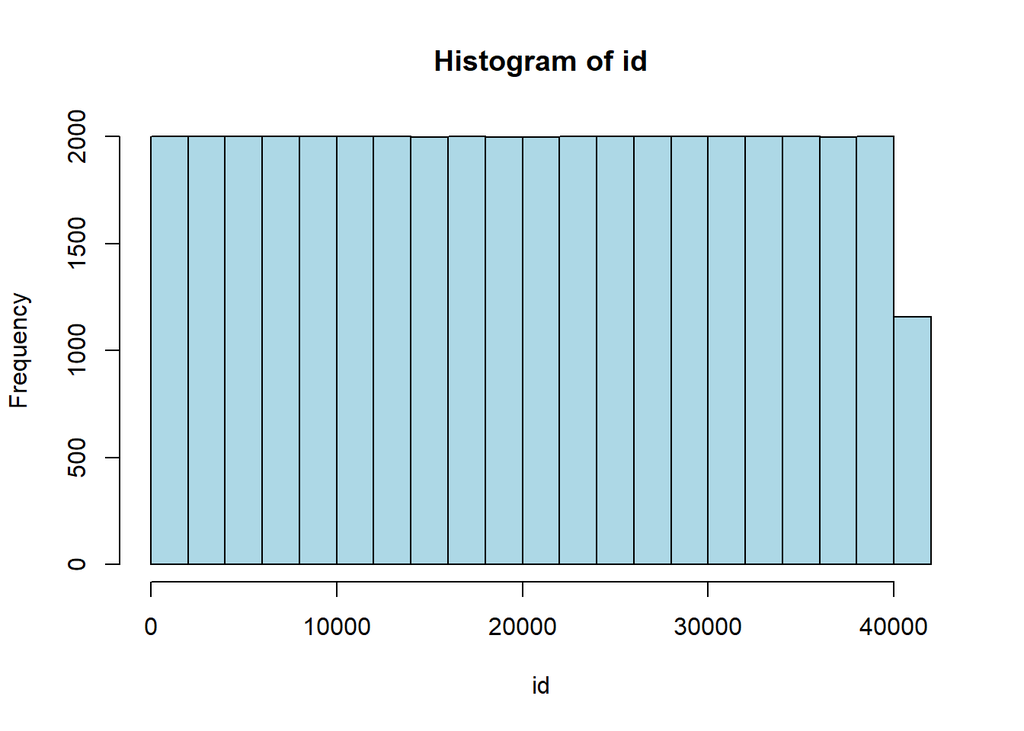

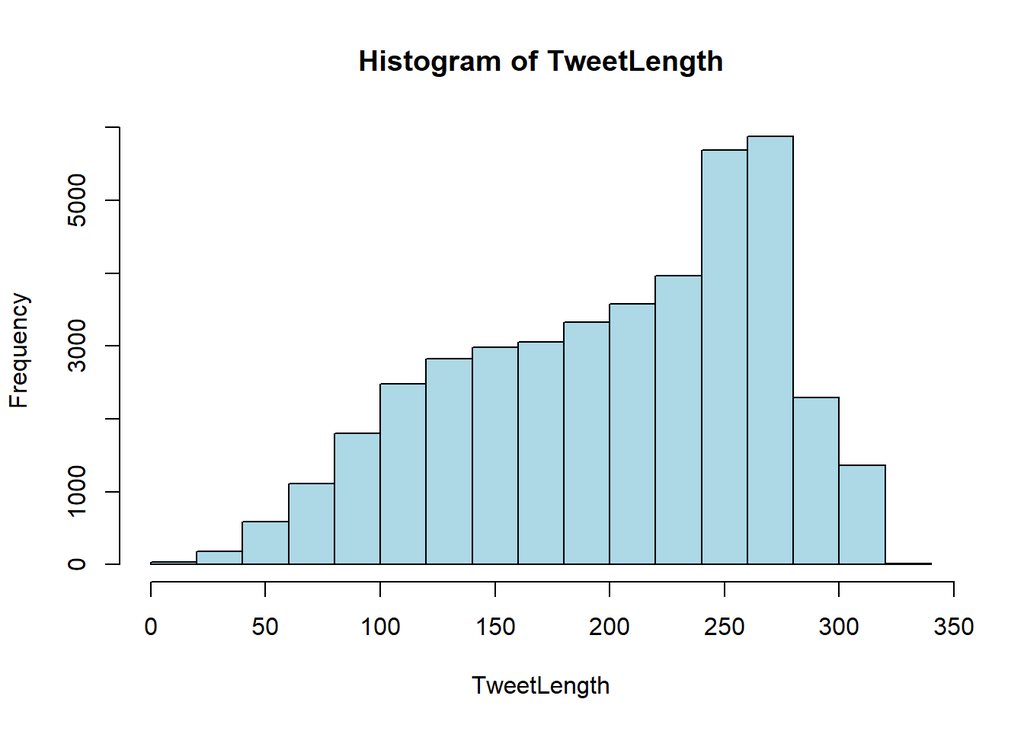

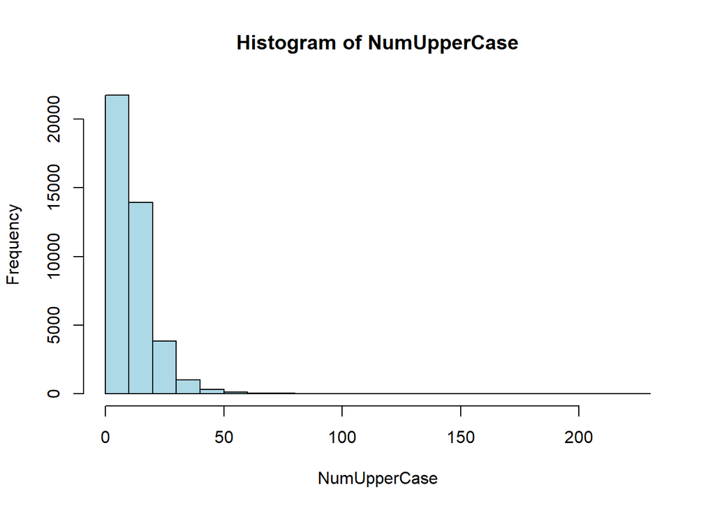

```r
data <- data %>%
  mutate(TweetAt = as.Date(data$TweetAt, format = "%d-%m-%Y"))

hist_data <- data[,-c(2,3,4,5,8,9)]
for (j in 1:ncol(hist_data)) {
  hist(hist_data[,j], xlab=colnames(hist_data)[j],
       main=paste("Histogram of", colnames(hist_data)[j]),
       col="lightblue", breaks=20)
}
```

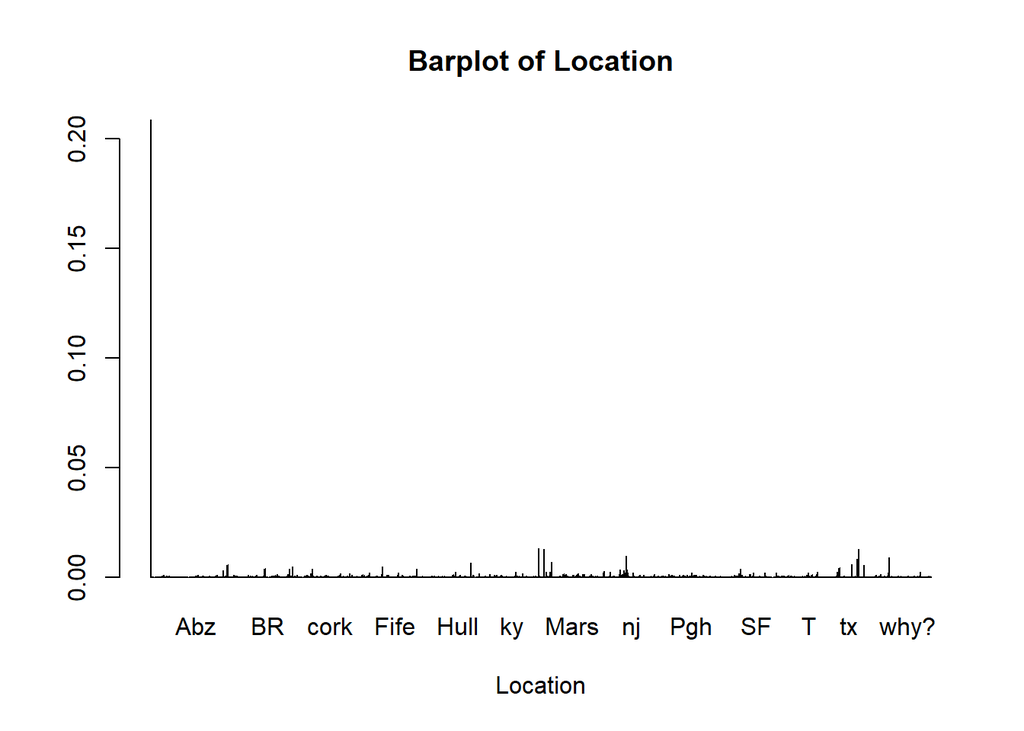

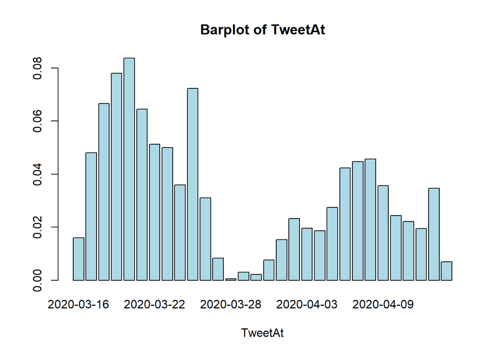

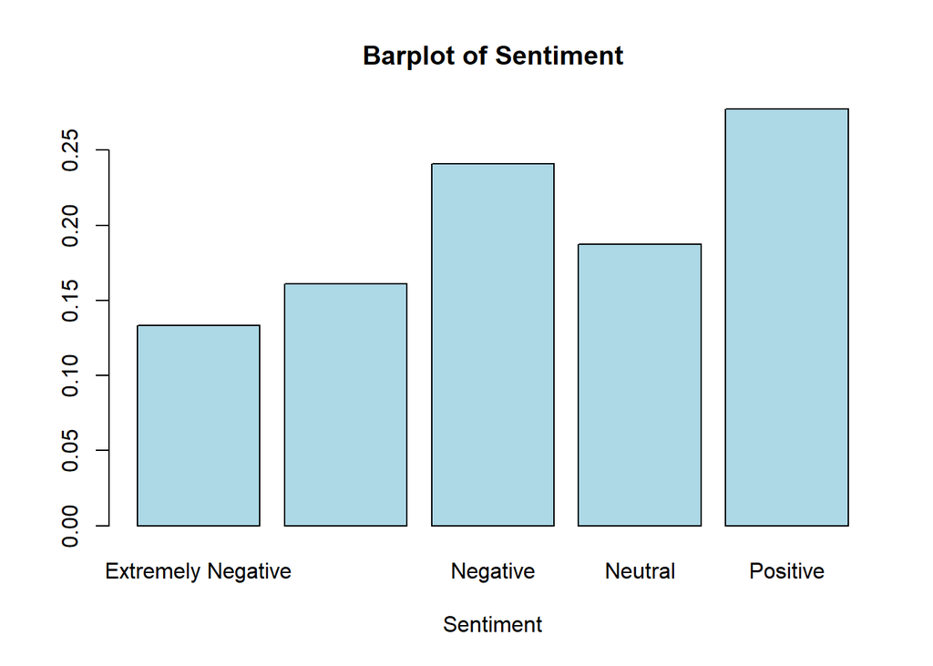

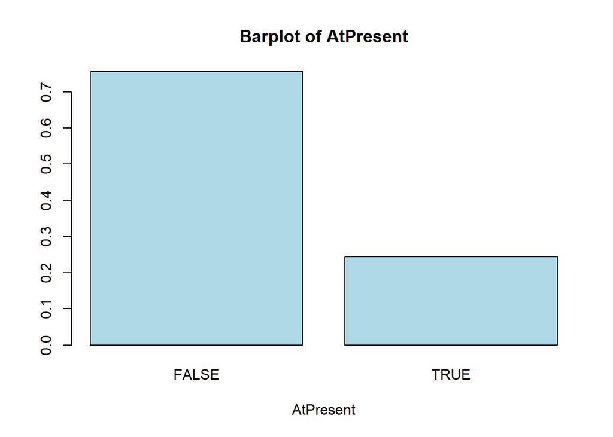

```r
bar_data <- data[,-c(1,4,6,7,9)]
for (j in 1:ncol(bar_data)) {
  barplot(prop.table(table(iconv(bar_data[,j], "UTF-8", "UTF-8",sub=''))), xlab=colnames(bar_data)[j],
       main=paste("Barplot of", colnames(bar_data)[j]),
       col="lightblue", breaks=20)
}
```

## Word frequencies

Since our data involves natural language, we are interested in the words. We have already tokenized the tweets, but we are still interested in what words are used.

```r
words = c()
for (i in 1:nrow(data)) {
  for (j in 1:length(data[i,]$tokenized)) {
    words[i*j] = data[i,]$tokenized[[1]][j]
  }
}
```

```r
Top_100_words = sort(table(words), decreasing = TRUE)[1:100]
head(Top_100_words)
```

```
## words
##  The    I   If    A This   We
## 1720 1319  567  547  540  526
```

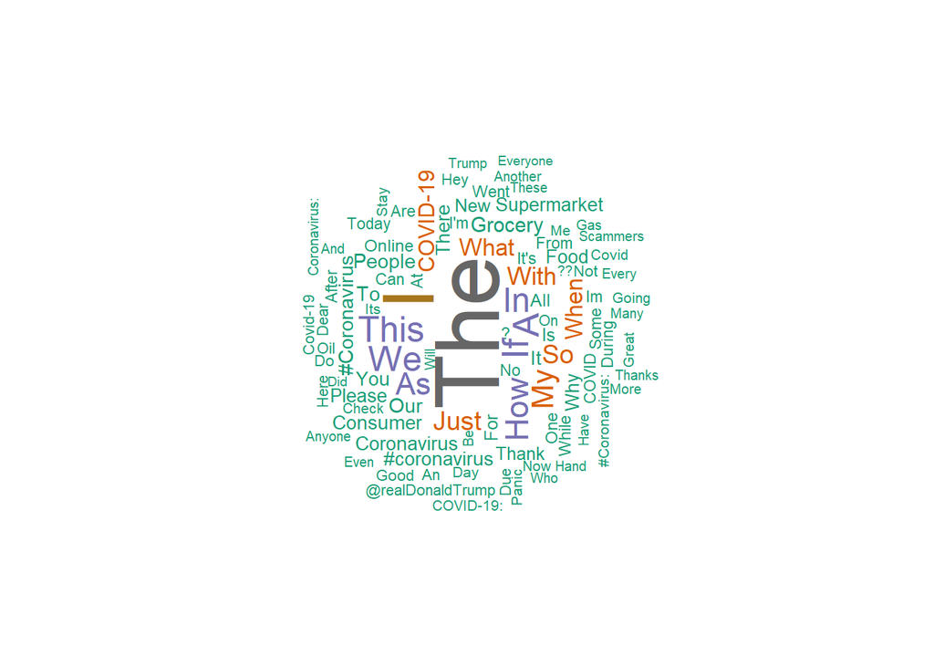

```r
set.seed(1234) # for reproducibility
wordcloud(words = dimnames(Top_100_words)$words, freq = as.numeric(Top_100_words), min.freq = 1,           max.words=200, random.order=FALSE, rot.per=0.35,            colors=brewer.pal(8, "Dark2"))
```

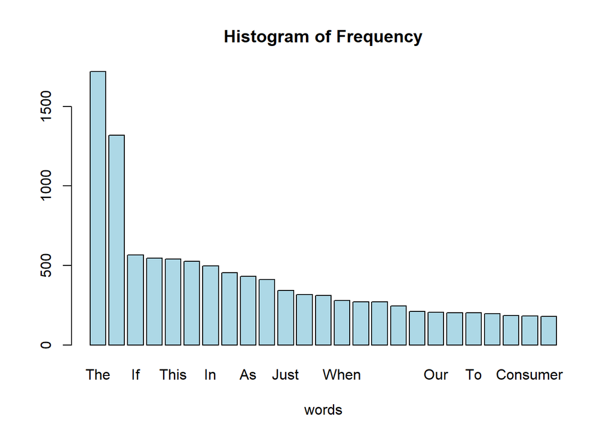

```r
barplot(Top_100_words[1:25], xlab="words",
       main=paste("Histogram of Frequency"),
       col="lightblue")
```

We use a word cloud plot and a barplot to show the top used words. We can see words like “The” and “I” takes a big part, which makes sense. The presence of “How,” “What,” and “When” suggests that people have question and are somewhat confused. We can also observe words such as “COVID-19,” “#COVID,” “food” and “grocery.” These words reflect what the users concerns are and can give us a brief intuition of the investigation of “Sentiment.” Interestingly, “Trump” was one of the top words used.

## Correlation between the variables

```r
cor_data <- data %>%
  mutate(Location = as.numeric(Location), TweetAt = as.numeric(TweetAt), Sentiment = as.numeric(Sentiment))
pros.cor = cor(cor_data[,c(2,3,5,6,7,8)])
round(pros.cor,3)
```

```
##              Location TweetAt Sentiment TweetLength NumUpperCase AtPresent
## Location        1.000  -0.004     0.009       0.010        0.019    -0.009
## TweetAt        -0.004   1.000     0.029      -0.031        0.035     0.019
## Sentiment       0.009   0.029     1.000      -0.146       -0.020     0.005
## TweetLength     0.010  -0.031    -0.146       1.000        0.284     0.170
## NumUpperCase    0.019   0.035    -0.020       0.284        1.000     0.129
## AtPresent      -0.009   0.019     0.005       0.170        0.129     1.000
```

```r
# rearrange the levels
data$Sentiment <- factor(data$Sentiment, levels = c("Extremely Negative","Negaive","Neutral","Positive","Extremely Positive"))
levels(data$Sentiment)
```

```
## [1] "Extremely Negative" "Negaive"            "Neutral"
## [4] "Positive"           "Extremely Positive"
```

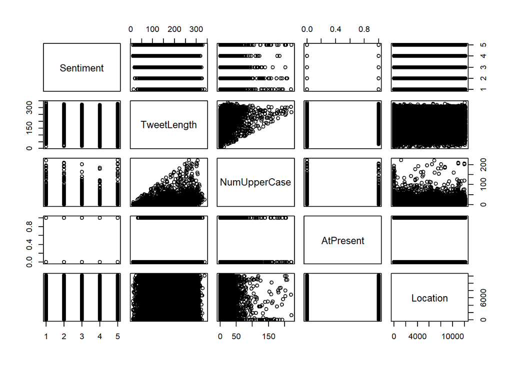

```r
pairs(~ Sentiment + TweetLength + NumUpperCase + AtPresent + Location, data=cor_data)
```

This plot is hard to interpret because most of the variables are factors. We try to use boxplot to compare the means.

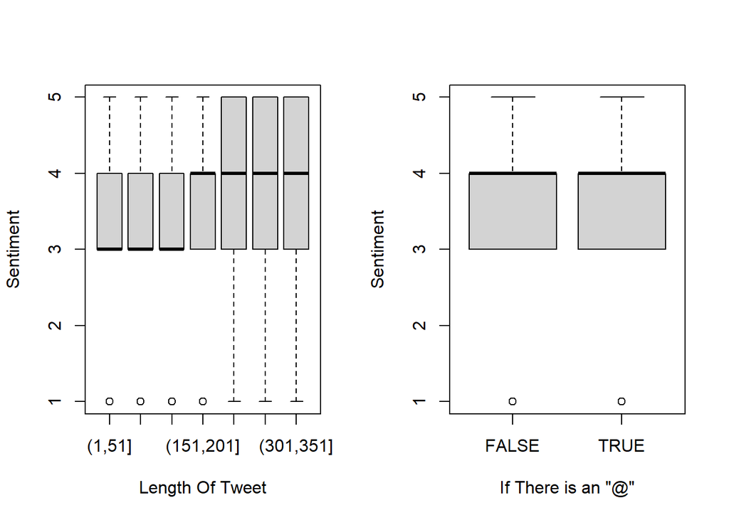

```r
par(mfrow=c(1,2))
data <- data %>%
  mutate(LengthRange = cut(data$TweetLength, breaks = seq(from=1, to=400, by=50)), upperRange = cut(data$NumUpperCase, breaks = seq(from=1, to=400, by=50)))

boxplot(Sentiment~LengthRange, data=data, main="",
     xlab="Length Of Tweet", ylab="Sentiment")
boxplot(Sentiment~AtPresent, data=data, main="",
     xlab="If There is an \"@\"", ylab="Sentiment")
```

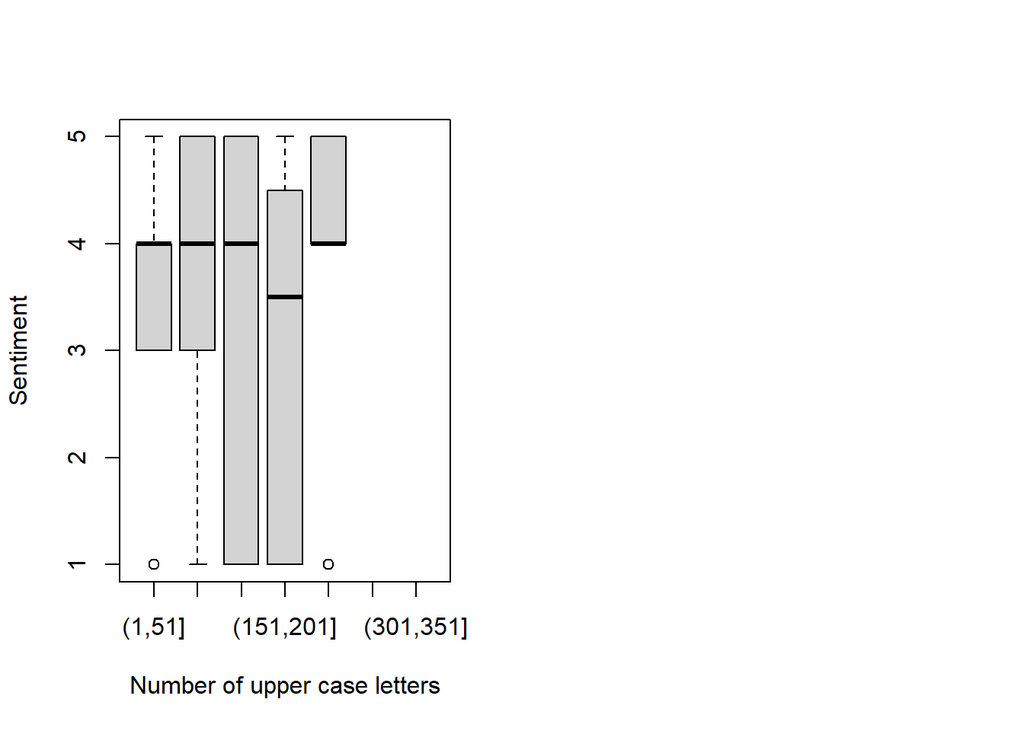

```r
boxplot(Sentiment~upperRange, data=data, main="",
     xlab="Number of upper case letters", ylab="Sentiment")
```

From the boxplot, we see that the increase of length of the tweets does show a positive trend in increasing the sentiment. Whether there is an “@” does not show clear realtion with the sentiment. If the number of upper case character in the tweet is small, the sentiment is generanllg not bad, but when the number increases, the variance also increases, suggesting both happy and non happy people tend to use more upper case characters.

# Preliminary ideas on what techniques we are going to apply

Our goal is to classify the mental state. We are going to mainly use the techniques we learned in this class: * Logistic Regression * Classification (including Naive Bayes and other subset) * Recurrent Neural Network